# Lecture 33: Inference for Regression

Chapter 23 (continued)

Corinne Riddell (Instructor: Alan Hubbard)

November 15, 2023

# Recap

- Last class we covered the assumptions necessary to perform linear regression
- Most of these assumptions can be investigated using plots of the residuals
- One of the assumptions could not be checked using plots. Which assumption was that?

# Recap on notation

| Term | Population | Sample |
| --- | --- | --- |
| Intercept | $a$ or $\alpha$ | $\hat{a}$ |
| Slope | $b$ or $\beta$ | $\hat{b}$ |
| Residual | $e$ | $\hat{e}$ |

# Learning objectives for today

- Conduct a hypothesis test for the slope parameter.
  - Define the test statistic
  - Know how to calculate the test using R output after running `lm()`
- Create a 95% **confidence interval** for the slope parameter
- Create a 95% **confidence interval** for the predicted value, and a 95% **prediction interval** for an individual value. Know how to explain the difference between the two
- Describe why the hypothesis test for correlation is the same (i.e., gives the same results) as the hypothesis test of the slope parameter

# Frog data

Recall the frog data from last class on temperature and the frequency of mating calls:

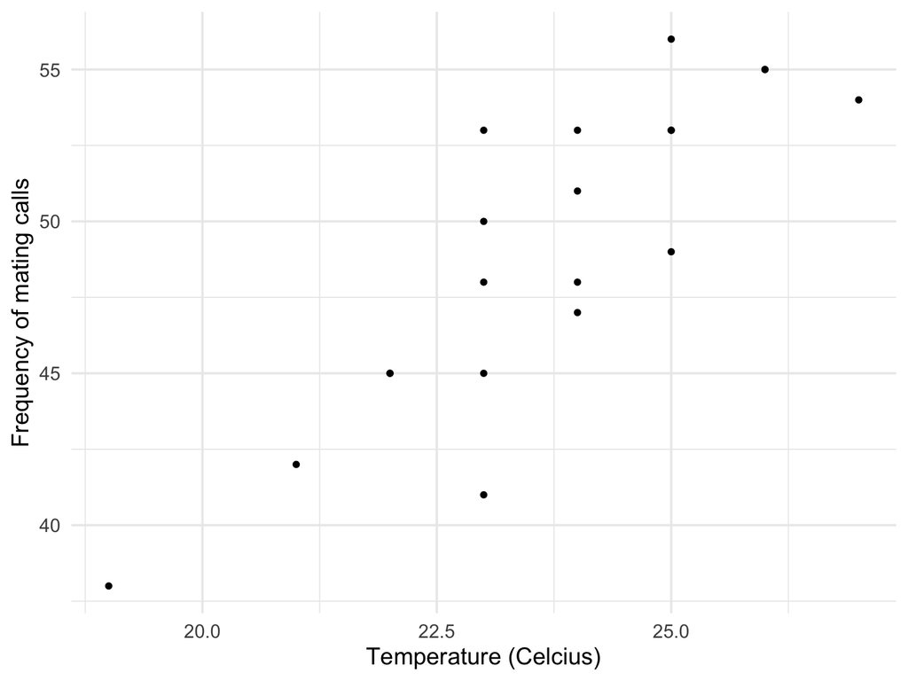

# Use `lm()` + `broom` functions to look at your linear model

- `tidy(your_lm)`: Presents the output of the linear model in a tidy way
- `glance(your_lm)`: Takes a quick (one line) look at the fit statistics.
- `augment(your_lm)`: Creates an augmented data frame that contains a column for the fitted y-values ($\hat{y}$) and the residuals ($\hat{e} = y-\hat{y}$) among other columns (you don’t need to worry about the other columns that are added)

Know these functions, what they do, and how to use them.

# Use `lm()` + `broom` functions to look at your linear model

```r
frog_lm <- lm(formula = freq ~ temp, data = frog_data)
tidy(frog_lm)
```

```
## # A tibble: 2 × 5
##   term        estimate std.error statistic    p.value
##   <chr>          <dbl>     <dbl>     <dbl>      <dbl>
## 1 (Intercept)    -6.19     8.24     -0.751 0.462
## 2 temp            2.33     0.347     6.72  0.00000266
```

```r
glance(frog_lm)
```

```
## # A tibble: 1 × 12
##   r.squared adj.r.squared sigma statistic    p.value    df logLik   AIC   BIC
##       <dbl>         <dbl> <dbl>     <dbl>      <dbl> <dbl>  <dbl> <dbl> <dbl>
## 1     0.715         0.699  2.82      45.2 0.00000266     1  -48.1  102.  105.
## # ℹ 3 more variables: deviance <dbl>, df.residual <int>, nobs <int>
```

```r
frog_data_aug <- augment(frog_lm)
head(frog_data_aug)
```

```
## # A tibble: 6 × 8
##    freq  temp .fitted  .resid   .hat .sigma   .cooksd .std.resid
##   <dbl> <dbl>   <dbl>   <dbl>  <dbl>  <dbl>     <dbl>      <dbl>
## 1    38    19    38.1 -0.0952 0.384    2.90 0.000575     -0.0430
## 2    42    21    42.8 -0.757  0.160    2.90 0.00816      -0.293
## 3    45    22    45.1 -0.0876 0.0937   2.90 0.0000550    -0.0326
## 4    45    22    45.1 -0.0876 0.0937   2.90 0.0000550    -0.0326
## 5    41    23    47.4 -6.42   0.0574   2.42 0.167        -2.34
## 6    45    23    47.4 -2.42   0.0574   2.84 0.0237       -0.883
```

- Only need to pay attention to the added columns `.fitted` and `.resid`

# New terminology: SSE

Sum of squared estimates of error (**SSE**): $SSE=\sum_i^n(y_i-\hat{y_i})^2$

- The SSE is the summation of the squared distance between each individual’s $y$ value and the fitted (or predicted) value based on the line of best fit
- The higher the **SSE** the worse the model fits the data

We are interested in knowing the average spread of the squared residual distances. Because small spread would indicate a good fitting model. To measure this, we calculate the **regression standard error**

# New terminology: Regression standard error

- The regression standard error can be calculated as: $s = \sqrt{\frac{1}{n-2}\times SSE}$
- This can also be written as:
  $$s =
  \sqrt{\frac{1}{n-2}\sum_{i=1}^{n}{\hat{e}^2}}$$
  or:
  $$s =
  \sqrt{\frac{1}{n-2}\sum_{i=1}^{n}{(y-\hat{y})^2}}$$
- We divide by $n-2$ rather than $n$ because this produces an unbiased estimate of $s$.
- A good-fitting model will have a low regression standard error because $\hat{y}$ will be close to y.
- Look at $s$ after running a linear model to assess the model’s fit to the data.
- $s$ is on the same scale as $y$ (i.e., they have the same units).
- `glance(your_lm)` prints $s$, which is denoted by `sigma`.

# `glance()` to view the regression standard error

```r
glance(frog_lm)
```

```
## # A tibble: 1 × 12
##   r.squared adj.r.squared sigma statistic    p.value    df logLik   AIC   BIC
##       <dbl>         <dbl> <dbl>     <dbl>      <dbl> <dbl>  <dbl> <dbl> <dbl>
## 1     0.715         0.699  2.82      45.2 0.00000266     1  -48.1  102.  105.
## # ℹ 3 more variables: deviance <dbl>, df.residual <int>, nobs <int>
```

- $sigma = 2.82$. This is the residual estimated standard deviation (or sometimes called residual standard error).

# Another way to contextualize the regression standard error

You can compute a five number summary on the residuals using the augmented data frame:

```r
frog_data_aug %>% summarise(min_resid = min(.resid),
                            q25_resid = quantile(.resid, 0.25),
                            mean_resid = mean(.resid),
                            q75_resid = quantile(.resid, 0.75),
                            max_resid = max(.resid))
```

```
## # A tibble: 1 × 5
##   min_resid q25_resid mean_resid q75_resid max_resid
##       <dbl>     <dbl>      <dbl>     <dbl>     <dbl>
## 1     -6.42     -1.92  -8.88e-15      1.00      5.58
```

- The smallest residual is -6.42 and the largest is 5.58.
- The IQR for the residuals goes from -1.92 to 1.00.
- The mean residual is very close to 0.
- **The residual standard error (2.82) is capturing the standard deviation of this distribution of residuals.**

# Hypothesis testing for regression

- The regression standard error is used as part of the test statistic for the slope coefficient
- In this test, we’d like to know whether the slope is different from 0. That is $H_0: b=0$ and $H_A: b \neq 0$ for a two-sided test.

# Frog data showing the estimates slope vs. null hypothesis slope

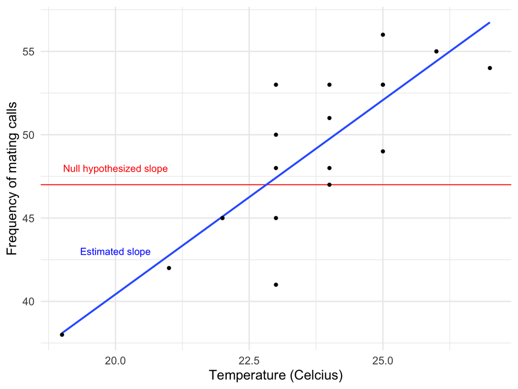

# Hypothesis testing for regression

What are the null and alternative hypotheses?

# Hypothesis testing for regression

$H_0: b=0$ (i.e., There is no association between temperature and the frequency of mating calls)

$H_a: b\neq 0$ (i.e., There is an association between temperature and the frequency of mating calls)

# Hypothesis testing for regression

$H_0: b=0$ (i.e., There is no association between temperature and the frequency of mating calls)

$H_a: b\neq 0$ (i.e., There is an association between temperature and the frequency of mating calls)

To test the null hypothesis, the t-test statistic is:

$$t = \frac{\hat{b}}{SE_b}$$

where $SE_b = \frac{s}{\sqrt{\sum(x-\bar{x})^2}}$ and $s = \sqrt{\frac{1}{n-2}\sum_{i=1}^{n}{(y-\hat{y})^2}}$

We will use R to compute the test statistic, $SE_b$ and $s$. Be sure you know where $SE_b$, $s$, and $\hat{b}$ can be found using the R output and which functions to use to find them.

# Two-sided hypothesis testing for regression using `tidy()`

```r
tidy(frog_lm)
```

```
## # A tibble: 2 × 5
##   term        estimate std.error statistic    p.value
##   <chr>          <dbl>     <dbl>     <dbl>      <dbl>
## 1 (Intercept)    -6.19     8.24     -0.751 0.462
## 2 temp            2.33     0.347     6.72  0.00000266
```

Focus on the row of data for `temp`:

- `estimate` is the estimated slope coefficient $\hat{b}$: 2.33
- `std.error` is the standard error, $SE_b = 0.347$
- `statistic` is the t-test statistic: $\frac{\hat{b}}{{SE}_b} = 2.330816/0.3467893 = 6.72$
- The test has $n-2$ degrees of freedom, where $n$ is the number of observations in the data frame.
- `p-value` is the p-value corresponding to the test

```r
pt(q = 6.7211302, df = 18, lower.tail = F)*2
```

```
## [1] 2.663401e-06
```

# Confidence intervals for the regression coefficient

We can also use the output from `tidy(your_lm)` to create a 95% confidence interval for the slope coefficient.

$\text{estimate}\pm \text{margin of error}$

$\hat{b} \pm t^*{SE}_b$

Where $t^*$ is the critical value for the t distribution with $n-2$ degrees of freedom with area C (e.g., 95%) between $-t^*$ and $t^*$.

# Confidence intervals for the regression coefficient

```r
tidy(frog_lm)
```

```
## # A tibble: 2 × 5
##   term        estimate std.error statistic    p.value
##   <chr>          <dbl>     <dbl>     <dbl>      <dbl>
## 1 (Intercept)    -6.19     8.24     -0.751 0.462
## 2 temp            2.33     0.347     6.72  0.00000266
```

First, find the critical value $t^*$, such that 95% of the area is between $t^*$ and $-t^*$:

```r
t_star <- qt(p = 0.975, df = 18)
t_star
```

```
## [1] 2.100922
```

95% CI:

$2.330816 \pm t^*0.3467893$

$2.330816 \pm 2.100922\times0.3467893$

95% CI: 1.60 to 3.06

Interpretation: The estimate for the slope coefficient is 2.33 (95% CI: 1.60 to 3.06). If we had gather 100 random samples and ran the same regress on each of them and used the same method to compute the 95% CI, 95 out of the 100 intervals would contain the true value of $\beta$ in the interval.

# Code for the confidence interval

Alternatively you can use the following code to calculate the confidence interval in R:

```r
confint(frog_lm, "temp")
```

```
##         2.5 %   97.5 %
## temp 1.602239 3.059393
```

# Inference for prediction

- So far we’ve learned only about inference for the slope coefficient $b$.
- But what if you wanted to use the model to make a prediction?
- We already know how to predict the **average** number of mating calls corresponding to a specific $x$ value, say of 21 degrees celcius:

$\hat{y} = -6.190332 + 2.330816x$

$\hat{y} = -6.190332 + 2.330816(21) = 42.8$

We expect 42.8 mating calls, so 43 mating calls (rounding because the outcome is a discrete variable) when the temperature is 21 degrees celcius.

# Inference for prediction

How do we make a confidence interval for this prediction?

- It depends on whether you want to make a CI for the **average response** or for an **individual’s response**

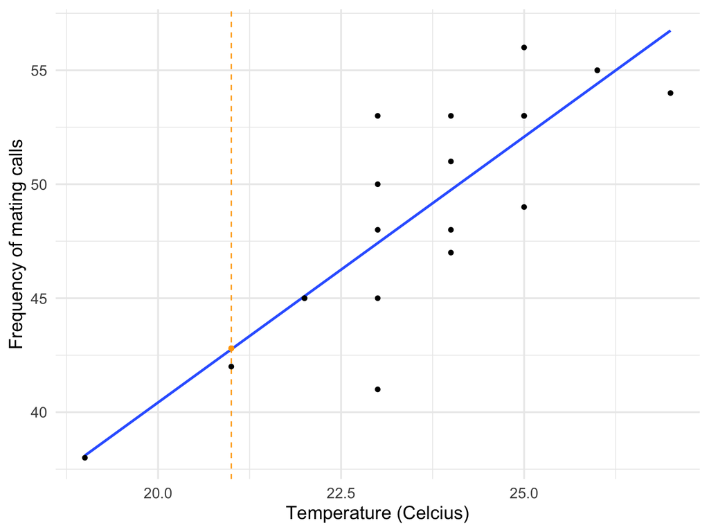

# Inference for prediction of average vs. individual response, visualized

If you want to make inference for the **mean response $\mu_y$** when $x$ takes the value $x^*$ (x*=21 in our example):

$\hat{y} \pm t*SE_{\hat{\mu}}$, where $SE_{\hat{\mu}}=s\sqrt{\frac{1}{n} + \frac{(x^*-\bar{x})^2}{\sum(x-\bar{x})^2}}$

If you want to make inference for a **single observation $y$** when $x$ takes the value $x^*$ (x*=21 in our example):

$\hat{y} \pm t*SE_{\hat{y}}$, where $SE_{\hat{y}}=s\sqrt{1 + \frac{1}{n} + \frac{(x^*-\bar{x})^2}{\sum(x-\bar{x})^2}}$

# Corresponding R code for `predict`ion and `confidence` interval:

```r
# specify the value of the explanatory variable for which you want the prediction:
newdata = data.frame(temp = 21)

# use `predict()` to make prediction and confidence intervals
prediction_interval <- predict(frog_lm, newdata, interval = "predict")
prediction_interval
```

```
##       fit      lwr      upr
## 1 42.7568 36.37187 49.14173
```

```r
confidence_interval <- predict(frog_lm, newdata, interval = "confidence")
confidence_interval
```

```
##       fit      lwr      upr
## 1 42.7568 40.38472 45.12887
```

# Inference for prediction, visualized

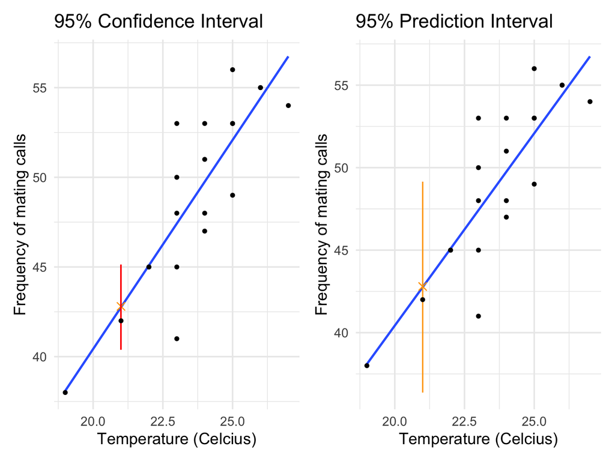

- Why is the prediction interval *wider* than the confidence interval?

# Test for a lack of correlation

- A lack of correlation occurs if and only if there is no association between the explanatory and response variables
- Thus, if your hypothesis test does not reject the null ($b = 0$) than this also implies that you would not reject the hypothesis of no correlation between x and y.
- Can you describe the steps of a permutation test to test for a lack of correlation?
- Don’t worry about the book section on this topic “Testing lack of correlation”